# Correlated Data

BMLR Chapter 7

Author

Affiliation

Ann Cannon

Cornell College  
STA 363 Fall 2026 Block 1

## Setup

```r
library(tidyverse)
library(tidymodels)
library(GGally)
library(knitr)
library(patchwork)
library(viridis)
library(ggfortify)
library(gridExtra)
library(kableExtra)
```

## Learning goals

- Recognize a potential for correlation in a data set
- Identify observational units at varying levels
- Understand issues correlated data may cause in modeling
- Understand how random effects models can be used to take correlation into account

# Correlated observations

## Examples of correlated data

- In an education study, scores for students from a particular teacher are typically more similar than scores of other students with a different teacher
- In a study measuring depression indices weekly over a month, the four measures for the same patient tend to be more similar than depression indices from other patients
- In political polling, opinions of members from the same household tend to be more similar than opinions of members from another household

. . .

Correlation among outcomes within the same group (teacher, patient, household) is called **intraclass correlation**

## Multilevel data

- We can think of correlated data as a multilevel structure
  - Population elements are aggregated into groups
  - There are observational units and measurements at each level
- For now we will focus on data with two levels:
  - **Level one**: Most basic level of observation
  - **Level two**: Groups formed from aggregated level-one observations
- Example: political polling
  - Level one: individual members of household
  - Level two: household

## Two types of effects

- **Fixed effects**: Effects that are of interest in the study
  - Can think of these as effects whose interpretations would be included in a write up of the study
- **Random effects**: Effects we’re not interested in studying but whose variability we want to understand
  - Can think of these as effects whose interpretations would not necessarily be included in a write up of the study

## Example

Researchers are interested in understanding the effect social media has on opinions about a proposed economic plan. They randomly select 1000 households. They ask each adult in the household how many minutes they spend on social media daily and whether they support the proposed economic plan.

- daily minutes on social media is the fixed effect
- household is the random effect

## Practice

*Researchers conducted a randomized controlled study where patients were randomly assigned to either an anti-epileptic drug or a placebo. For each patient, the number of seizures at baseline was measured over a 2-week period. For four consecutive visits the number of seizures were determined over the past 2-week period. Patient age and sex along with visit number were recorded.*

. . .

*Questions*

1. What are the level one and level two observational units?
2. What is the response variable and what is its type (normal, Poisson, etc.)?
3. Describe the within-group variation.
4. What are the fixed effects? What are the random effects?

Ex. 1 from Section 7.10.1 in BMLR

# Teratogen and rat pups

## Data: Teratogen and rat pups

Today’s data are simulated results of an experiment with 24 dams (mother rats) randomly divided into four groups that received different doses of teratogen, a substance that could potentially cause harm to developing fetuses. The four groups are

- High dose (3 mg)
- Medium dose (2 mg)
- Low dose (1 mg)
- No dose (Control)

. . .

Each dam produced 10 rat pups and the presence of a deformity was noted.

. . .

**Goal**: Understand the association between teratogen exposure and the probability a pup is born with a deformity.

# Scenario 1: No dose effect

## Scenario 1: No dose effect

Assume dose has no effect on, $p$, the probability of a pup born with a deformity.

- **Scenario 1a.**: $p = 0.5$ for each dam
- **Scenario 1b.**: $p \sim Beta(0.5, 0.5)$ (expected value = 0.5)

. . .

## Scenario 1: No dose effect

**Ouput**

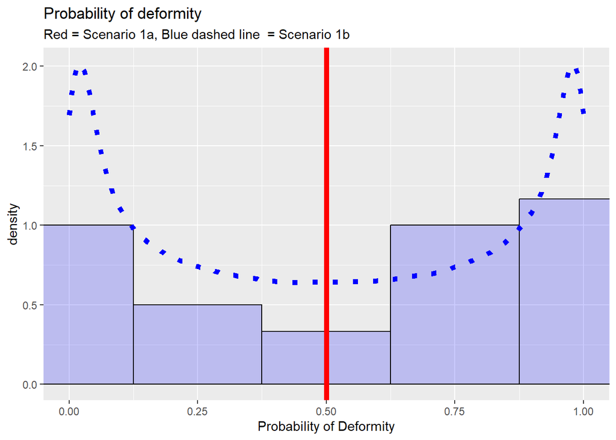

**Code**

```r
theoretical_pi <- tibble(x = 1:250000,
                         p1 = rbeta(x, 0.5, 0.5))

tibble(x = 1:24, pi_1b) |>
  ggplot() +
    geom_histogram(bins = 5, aes(x = pi_1b, y = ..density..),
                   color = "black", fill = "blue", alpha = 0.2) +
    coord_cartesian(xlim = c(0,1)) +
    geom_density(data = theoretical_pi, aes(x = p1),
                  linetype = 3, color = "blue", lwd = 2) +
    geom_vline(xintercept = 0.5, color = "red", lwd = 2) +
    labs(title = "Probability of deformity",
         subtitle = "Red = Scenario 1a, Blue dashed line  = Scenario 1b",
         x = "Probability of Deformity")
```

From Figure 7.1 in BMLR

## Questions

1. Would you expect the number of pups with a deformity for dams in Scenario 1a to follow a distribution similar to the binomial distribution with $n=10$ and $p=0.5$? Why or why not?
2. Would you expect the number of pups with a deformity for dams in Scenario 1b to follow a distribution similar to the binomial distribution with $n=10$ and $p=0.5$? Why or why not?
3. Which scenario do you think is more realistic - Scenario 1a or 1b?

## Investigating

**Output**

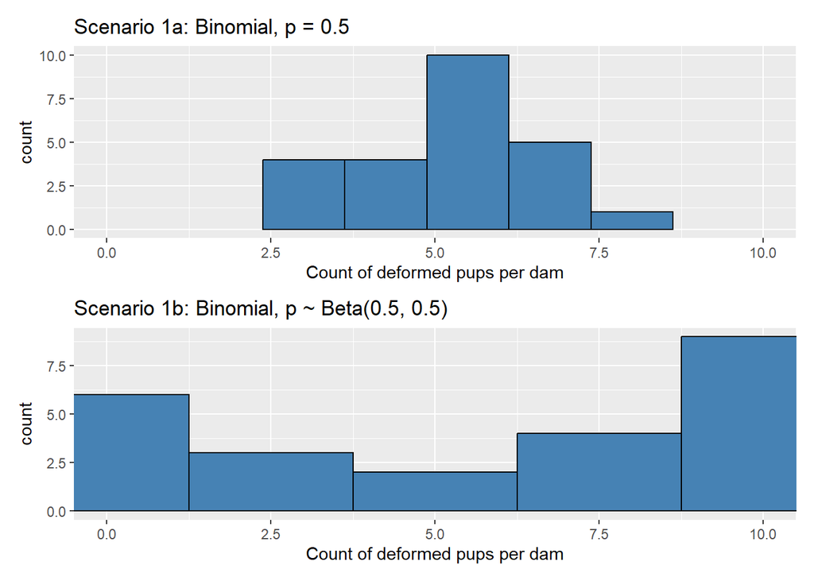

| mean_1a | sd_1a | mean_1b | sd_1b |
| --- | --- | --- | --- |
| 5.166667 | 1.493949 | 5.666667 | 4.103727 |

**Code**

```r
pi_1a <- rep(0.5, 24)
count_1a <- rbinom(24, 10, pi_1a)

pi_1b <- rbeta(24,.5,.5)
count_1b <- rbinom(24, 10, pi_1b)
```

```r
scenario_1 <-
  tibble(pi_1a, count_1a, pi_1b, count_1b) |>
  mutate(phat_1a = count_1a / 10,
         phat_1b = count_1b / 10)

hist_1a <- ggplot(data = scenario_1, aes(x = count_1a)) +
  geom_histogram(bins = 5, color = "black", fill = "steelblue") +
  coord_cartesian(xlim = c(0, 10)) +
  labs(title = "Scenario 1a: Binomial, p = 0.5",
       x = "Count of deformed pups per dam")

hist_1b <- ggplot(data = scenario_1, aes(x = count_1b)) +
  geom_histogram(bins = 5, color = "black", fill = "steelblue") +
  coord_cartesian(xlim = c(0, 10)) +
  labs(title = "Scenario 1b: Binomial, p ~ Beta(0.5, 0.5)",
       x = "Count of deformed pups per dam")

hist_1a / hist_1b
```

```r
scenario_1 |>
  summarise(mean_1a = mean(count_1a), sd_1a = sd(count_1a),
            mean_1b = mean(count_1b), sd_1b = sd(count_1b) ) |>
  kable()
```

. . .

Let’s take a look at a binomial and quasibinomial model for Scenarios 1a and 1b.

## Model 1a Binomial

**Output**

| term | estimate | std.error | statistic | p.value |
| --- | --- | --- | --- | --- |
| (Intercept) | 0.067 | 0.129 | 0.516 | 0.606 |

95% confidence interval for the ODDS of a pup with deformity

```
    2.5 %    97.5 %
0.8298899 1.3778985
```

95% confidence interval for the PROBABILITY of a pup with a deformity

```
    2.5 %    97.5 %
0.4535190 0.5794606
```

**Code**

```r
model_1a <- glm(phat_1a ~ 1, family = binomial, weight = rep(10,24),
                data = scenario_1)

tidy(model_1a) |>
  kable(digits = 3)

#95% CI for the odds of a pup with deformity
exp(confint(model_1a))

#95% CI for the probability of a pup with deformity
exp(confint(model_1a)) / (1 + exp(confint(model_1a)))
```

**Output**

| term | estimate | std.error | statistic | p.value |
| --- | --- | --- | --- | --- |
| (Intercept) | 0.067 | 0.122 | 0.546 | 0.59 |

95% confidence interval for the ODDS of a pup with deformity

```
    2.5 %    97.5 %
0.8414573 1.3588535
```

95% confidence interval for the PROBABILITY of a pup with a deformity

```
    2.5 %    97.5 %
0.4569518 0.5760652
```

**Code**

```r
model_1a <- glm(phat_1a ~ 1, family = quasibinomial, weight = rep(10,24),
                data = scenario_1)

tidy(model_1a) |>
  kable(digits = 3)

#95% CI for the odds of a pup with deformity
exp(confint(model_1a))

#95% CI for the probability of a pup with deformity
exp(confint(model_1a)) / (1 + exp(confint(model_1a)))
```

## Model 1b Binomial

**Output**

| term | estimate | std.error | statistic | p.value |
| --- | --- | --- | --- | --- |
| (Intercept) | 0.268 | 0.13 | 2.059 | 0.039 |

95% confidence interval for the ODDS of a pup with deformity

```
   2.5 %   97.5 %
1.014156 1.691097
```

95% confidence interval for the PROBABILITY of a pup with a deformity

```
    2.5 %    97.5 %
0.5035141 0.6284043
```

**Code**

```r
model_1b <- glm(phat_1b ~ 1, family = binomial, weight = rep(10,24),
                data = scenario_1)

tidy(model_1b) |>
  kable(digits = 3)

#95% CI for the odds of a pup with deformity
exp(confint(model_1b))

#95% CI for the probability of a pup with deformity
exp(confint(model_1b)) / (1 + exp(confint(model_1b)))
```

## Model 1b Quasibinomial

**Output**

| term | estimate | std.error | statistic | p.value |
| --- | --- | --- | --- | --- |
| (Intercept) | 0.268 | 0.341 | 0.786 | 0.44 |

95% confidence interval for the ODDS of a pup with deformity

```
    2.5 %    97.5 %
0.6726041 2.5941021
```

95% confidence interval for the PROBABILITY of a pup with a deformity

```
    2.5 %    97.5 %
0.4021299 0.7217664
```

**Code**

```r
model_1b <- glm(phat_1b ~ 1, family = quasibinomial, weight = rep(10,24),
                data = scenario_1)

tidy(model_1b) |>
  kable(digits = 3)

#95% CI for the odds of a pup with deformity
exp(confint(model_1b))

#95% CI for the probability of a pup with deformity
exp(confint(model_1b)) / (1 + exp(confint(model_1b)))
```

## Compare Binom and Quasi

Odds confidence intervals

| 1A Binomial | 1A Quasi | 1B Binomial | 1B Quasi |
| --- | --- | --- | --- |
| (0.83, 1.38) | (0.84,1.36) | (1.01,1.69) | (0.67,2.59) |

Probability confidence intervals

| 1A Binomial | 1A Quasi | 1B Binomial | 1B Quasi |
| --- | --- | --- | --- |
| (0.45, 0.58) | (0.46,0.58) | (0.50,0.63) | (0.40,0.72) |

. . .

How does the quasibinomial analysis for Scenario 1b differ from the binomial analysis for Scenario 1b? Consider the coefficient estimates, standard error, predicted probabilities, and associated 95% CIs.

. . .

Why are differences between the quasibinomial models of Scenario 1a less noticeable than the differences in Scenario 1b?

# Scenario 2: Dose effect

## Scenario 2: Dose effect

- High dose (`dose = 3`)
- Medium dose (`dose = 2`)
- Low dose (`dose = 1`)
- No dose (`dose = 0`)

. . .

We will assume the true relationship between $p$ and dose is the following:

$$\log\Big(\frac{p}{1-p}\Big) = -2 + 1.33 ~ dose$$

## Scenario 2

**Scenario 2a.**

$$p = \frac{e^{-2 + 1.33 ~ dose}}{1 + e^{-2 + 1.33 ~ dose}}$$

. . .

**Scenario 2b.**:

$$p \sim Beta\Big(\frac{2p}{(1-p)}, 2\Big)$$

On average, dams who receive dose $x$ have the same probability of deformed pup as dams with dose $x$ under Scenario 2a.

## Distributions under Scenario 2

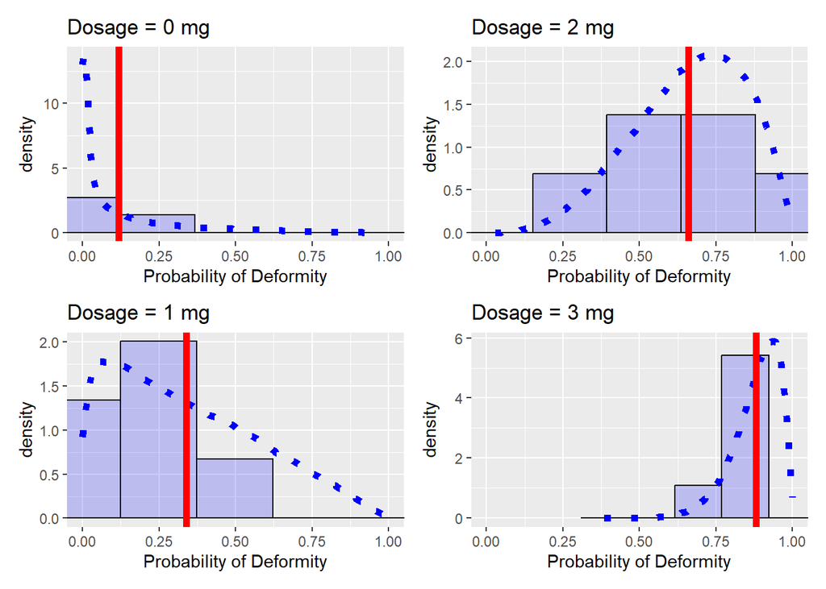

Replicated from Figure 7.3 in BMLR

## Summary stats under Scen.2

**Output**

| mean_2a | sd_2a | mean_2b | sd_2b |
| --- | --- | --- | --- |
| 4.791667 | 3.202976 | 4.666667 | 3.583375 |

Summary statistics of Scenario 2 by dose.

| Dosage | Scenario 2a Mean p | Scenario 2a SD p | Scenario 2a Mean Count | Scenario 2a SD Count | Scenario 2b Mean p | Scenario 2b SD p | Scenario 2b Mean Count | Scenario 2b SD Count |
| --- | --- | --- | --- | --- | --- | --- | --- | --- |
| 0 | 0.119 | 0 | 1.333 | 1.366 | 0.061 | 0.069 | 0.500 | 0.837 |
| 1 | 0.339 | 0 | 3.167 | 1.835 | 0.239 | 0.208 | 3.500 | 2.881 |
| 2 | 0.661 | 0 | 5.833 | 1.472 | 0.615 | 0.195 | 5.833 | 1.941 |
| 3 | 0.881 | 0 | 8.833 | 1.169 | 0.872 | 0.079 | 8.833 | 1.169 |

**Code**

```r
scenario_2 |>
  summarise(mean_2a = mean(count_2a), sd_2a = sd(count_2a),
            mean_2b = mean(count_2b), sd_2b = sd(count_2b) )
```

```r
scenario2Tab <- scenario_2 |>
                  group_by(dose) |>
                  summarise(mean_2a_pi = round(mean(pi_2a),3), sd_2a_pi = round(sd(pi_2a),3),
                            mean_2a_cnt = round(mean(count_2a),3), sd_2a_cnt = round(sd(count_2a),3),
                            mean_2b_pi = round(mean(pi_2b),3), sd_2b_pi = round(sd(pi_2b),3),
                            mean_2b_cnt = round(mean(count_2b),3), sd_2b_cnt = round(sd(count_2b),3)) |>
                  as.data.frame()
colnames(scenario2Tab) <- c("Dosage","Mean p", "SD p",
    "Mean Count", "SD Count", "Mean p", "SD p",
    "Mean Count", "SD Count")
kable(scenario2Tab, booktabs = T,
    caption="Summary statistics of Scenario 2 by dose.") |>
    add_header_above(c(" " = 1, "Scenario 2a" = 4,
                       "Scenario 2b" = 4)) |>
    kable_styling(latex_options = "scale_down") |>
    column_spec(c(4:5,8:9), width = "1cm")
```

From Table 7.2 in BMLR

## Questions

1. In Scenario 2a, dams produced 4.79 deformed pups on average, with standard deviation 3.20. Scenario 2b saw an average of 4.67 with standard deviation 3.58. Why are comparisons by dose more meaningful than these overall comparisons?
2. We will use binomial and quasibinomial regression to model the relationship between dose and probability of pup born with a deformity. What can you say about the center and the width of the confidence intervals under Scenarios 2a and 2b?
- Which will be similar and why?
- Which will be different and how?

## Scenario 2: Estimated odds ratio

*The estimated effect of dose and the 95% CI from the binomial and quasibinomial models are below:*

. . .

**Scenario 2a**

|  | Odds Ratio | 95% CI |
| --- | --- | --- |
| Binomial | 3.536 | (2.604, 4.958) |
| Quasibinomial | 3.536 | (2.512, 5.186) |

**Scenario 2b**

|  | Odds Ratio | 95% CI |
| --- | --- | --- |
| Binomial | 4.311 | (3.086, 6.271) |
| Quasibinomial | 4.311 | (2.735, 7.352) |

## Questions

1. Describe how the quasibinomial analysis of Scenario 2b differs from the binomial analysis of the same simulated data. Do confidence intervals contain the true model parameters? Is this what you expected? Why?
2. Why are differences between quasibinomial and binomial models of Scenario 2a less noticeable than the differences in Scenario 2b?